# Chicago Crime Analysis Part 1

Coleman Breen, Stephanie Cleland, Nathan Horswill

October 12, 2018

# Initial Exploration and Observations

[Chicago community areas](https://www.lib.uchicago.edu/e/collections/maps/uofcgis.html)

```r
library(plyr)
library(ggmap)
library(maps)
library(mapdata)
library(rgdal)
library(data.table)
library(sp)
library(ggalt)
library(tidyverse)
```

```r
crimes <- fread('chicago_crimes_2001_present.csv', header = TRUE, sep = ',', data.table = FALSE)
```

## Data cleaning

```r
#--> Rename variables to be tidyverse-compliant, drop columns
crimes2 <- crimes %>%
  rename(PrimaryType = 'Primary Type') %>%
  rename(LocationDescription = 'Location Description') %>%
  dplyr::select(-ID, -'Case Number', -IUCR, -Beat, -Block, -District, -Ward,
         -'Community Area', -'FBI Code', -'X Coordinate', -'Y Coordinate')

#--> What type of LocationDescriptions are there
head(unique(crimes2$LocationDescription))
```

```
## [1] "STREET"                         "APARTMENT"
## [3] "SIDEWALK"                       "RESIDENCE PORCH/HALLWAY"
## [5] "PARKING LOT/GARAGE(NON.RESID.)" "CTA GARAGE / OTHER PROPERTY"
```

For the sake of this analysis, we are concerned with public places.

```r
#--> Define public places
public_places <- c("STREET", "SIDEWALK", "ALLEY")

crimes3 <- crimes2 %>%
  filter(LocationDescription %in% public_places)
```

# Heat map

To create a heat map of crimes, we will want to overlay a few components. First, we want the occurences of crime. We also want to show the Chicago community area divisions, train stops, and train lines. We’ll have to build this up piece by piece. First, we’ll create the community area boundaries.

```r
#--> Convert to zipcodes from lat, long
comm_areas <- readOGR(dsn="chicago_comm_areas", layer="chicomm")
```

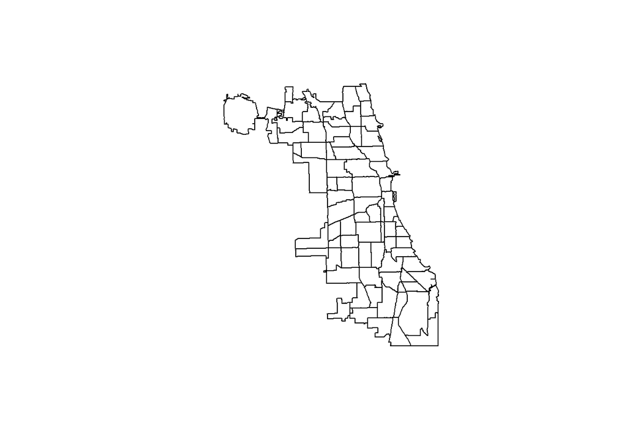

```r
plot(comm_areas)
```

We’ll convert the geographic coordinates of crimes into a form that we can easily overlay other features onto. Specifically, we’ll convert these coordinates into a `SpatialPointsDataFrame`.

```r
#--> Pull out the coordinates
coords <- crimes3[c("Longitude", "Latitude")]

#--> Filter out na
coords <- coords[, ] %>%
  filter(!is.na(Longitude)) %>%
  filter(!is.na(Latitude))

#--> COnvert to spatial points data frame
sp <- SpatialPointsDataFrame(coords = coords, data = coords)

#--> Fix projection
my_projection <- comm_areas@proj4string
proj4string(sp) <- my_projection

#--> Aggregate so that we can map by community area
ID <- over(sp, comm_areas )
crimes_agg <- cbind(sp@data, ID)
```

Now we will read in the coordinates of the individual train stations. We’ll have to do some cleaning to make these stop locations work with the `rgdal` and `sp` libraries.

```r
#--> Read in stops
stops <- fread('chicago_train_stops.csv', header = TRUE, sep = ',', data.table = FALSE)

#--> Clean
library(stringr)
stops$Location %>%
  str_remove_all("[(,)]") %>%
  str_split(" ") -> stop_locs

#--> Convert to a list of doubles
stop_locs <- as.numeric(unlist(stop_locs))

#--> Pull out lat/lon
stops_pts <- SpatialPoints(cbind(stop_locs[c(TRUE, FALSE)],stop_locs[c(FALSE, TRUE)]))
```

We’ll do a little bit more manipulation to make this mapping work.

```r
#--> Convert comm_areas to a data frame
comm_areas@data$id <- rownames(comm_areas@data)
comm_areas.points <- fortify(comm_areas, region = "id")
comm_areas.df <- plyr::join(comm_areas.points, comm_areas@data, by = "id")

#--> Make the stops into a normal df
stops_df <- as.data.frame(stops_pts)
colnames(stops_df) <- c("Latitude", "Longitude")
```

Finally, we need the train lines.

```r
#--> Read in the train lines
lines_shape <- readOGR("CTA_RailLines/CTA_RailLines.shp")
lines_shape <- spTransform(lines_shape, CRS("+proj=longlat +datum=WGS84"))
lines_shape_df <- fortify(lines_shape)
```

Finally, we can overlay all of these pieces to get an informative map.

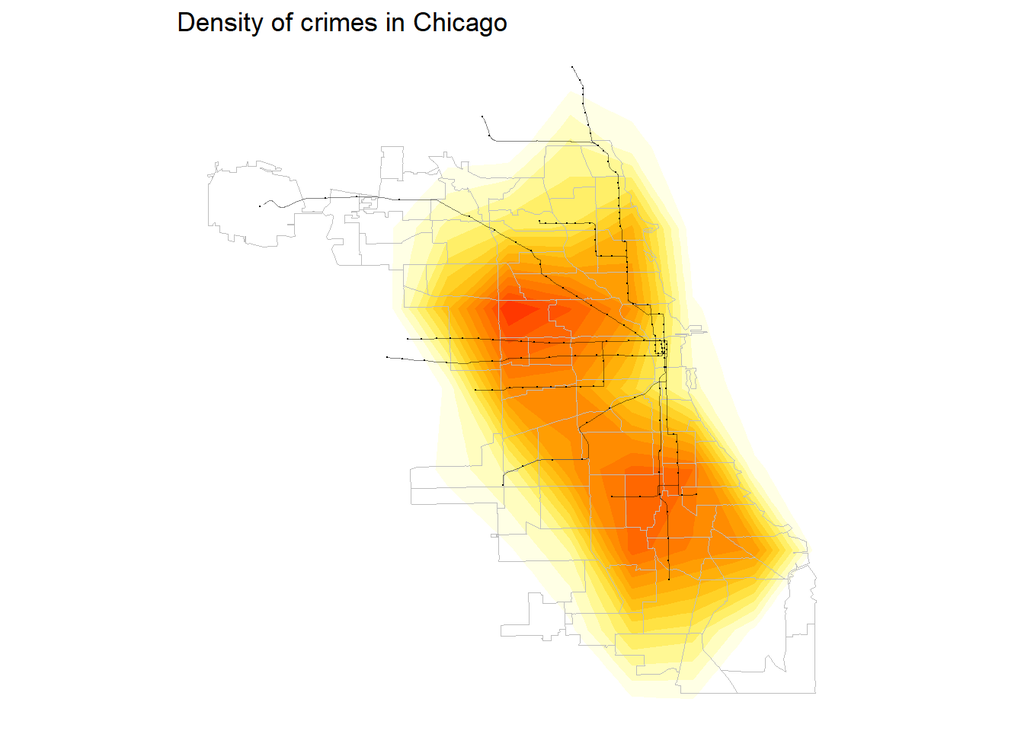

```r
#--> Sample  so that R to avoid memory issues
crimes4 <- sample_n(crimes3, 10000)
rm(crimes2, crimes3) # Free up RAM

#--> Plot as a heat map
chicago_plot <- ggplot(data = crimes4) +
  #--> Heat map of crimes
  stat_density2d(data = crimes4, show.legend = FALSE,
                 mapping = aes(x = Longitude, y = Latitude,
                               fill = ..level.., alpha = (..level..)*3),
                 geom="polygon", size=2, bins=15) +
  #--> Color the heat map
  scale_fill_gradient(low="yellow", high="red") +
  #--> Overlay the community areas
  geom_polygon(data=comm_areas.df,
               mapping=aes(x=long, y=lat, group=group),
               color="grey", size=.1, fill=NA) +
  #--> Overlay the train stops
  geom_point(data=stops_df, mapping=aes(x=Longitude, y=Latitude),
             color="black", size = .1) +
  #--> Overlay the train lines
  geom_path(data=lines_shape_df, aes(x = long, y = lat, group = group),
                color = "black", size = .3, alpha = 0.5) +
  #--> Fix the coordinate projection
  coord_proj(proj4string(comm_areas)) +
  #--> Style and title
  ggtitle("Density of crimes in Chicago") +
  theme_void()

chicago_plot
```

```r
#--> Free up RAM
rm(crimes4, chicago_plot)
```

# Explore Demographic Factors as Predictors of Crime

```r
#--> Count crimes_agg
crime_counts_df <- count(crimes_agg, CHICOMNO)

#--> Join the data
crime_counts_df <- crime_counts_df %>%
  dplyr::full_join(crimes_agg, by = 'CHICOMNO') %>%
  filter(!duplicated(CHICOMNO)) %>%
  filter(!is.na(CHICOMNO))

head(crime_counts_df)
```

```
## # A tibble: 6 x 11
##   CHICOMNO     n Longitude Latitude DISTNAME DISTITLE FAMINC HOUSINC
##   <fct>    <int>     <dbl>    <dbl>    <int> <fct>     <int>   <int>
## 1 0001     38655     -87.7     42.0        1 Rogers ~  27330   23902
## 2 0002     28863     -87.7     42.0        2 West Ri~  36791   31408
## 3 0003     38945     -87.7     42.0        3 Uptown    22378   19711
## 4 0004     16121     -87.7     42.0        4 Lincoln~  31403   26344
## 5 0005     14089     -87.7     41.9        5 North C~  34739   28941
## 6 0006     45711     -87.7     41.9        6 Lake Vi~  45981   31871
## # ... with 3 more variables: PERCAPINC <int>, MEDVALOOH <int>,
## #   MEDRENT <int>
```

We’ll add [US Census](https://datahub.cmap.illinois.gov/dataset/2010-census-data-summarized-to-chicago-community-areas/resource/b30b47bf-bb0d-46b6-853b-47270fb7f626) data to tell us the populations by age, race, gender, etc. based on community area.

```r
comm_demo_df <- read_csv("chicago_comm_areas/chicago_comm_areas_demographics.csv",
                      skip=1, col_names=TRUE)

#--> Clean up
names(comm_demo_df)[2] <- "ID"
comm_demo_df <- comm_demo_df[,1:67] # Before the variables become x1, x2, etc.

crime_counts_df %>%
  mutate("ID" = as.integer(CHICOMNO)) -> crime_counts_df

#--> Join with pop
crime_counts_df <- full_join(crime_counts_df, comm_demo_df, by="ID")
```

```r
#--> Clean up variable names a bit
names(crime_counts_df) %>%
  str_replace_all(" ", "") %>%
  str_replace_all(".x", "") %>%
  str_replace_all("NotHispanicorLatino,", "") -> names(crime_counts_df)

#--> Convert n to RawCounts"
names(crime_counts_df)[names(crime_counts_df) == "n"] <- "RawCounts"

#--> Calculate percentages, keep variables of interest
crime_counts_df %>%
  #mutate(NormCounts = (RawCounts * TotalPopulation / 100000) / 17) %>%
  mutate(NormCounts = RawCounts / 100000) %>%
  mutate(NormCounts = NormCounts / 17) %>%
  mutate(NormCounts = NormCounts * TotalPopulation) %>%
  dplyr::select(ID, NormCounts, RawCounts, TotalPopulation, everything())-> crime_counts_df
```

What community areas have the highest crime rate?

```r
#--> What community area has so many crimes?
head(crime_counts_df[order(crime_counts_df$NormCounts, decreasing=TRUE), ], 10)
```

```
## # A tibble: 10 x 79
##       ID NormCounts RawCounts TotalPopulation CHICOMNO Longitude Latitude
##    <int>      <dbl>     <int>           <int> <fct>        <dbl>    <dbl>
##  1    25     11954.    206283           98514 0025         -87.7     41.9
##  2    24      4332.     89544           82236 0024         -87.7     41.9
##  3    23      3539.    106831           56323 0023         -87.7     41.9
##  4     8      2861.     60440           80484 0008         -87.6     41.9
##  5     6      2537.     45711           94368 0006         -87.7     41.9
##  6    30      2536.     54374           79288 0030         -87.7     41.9
##  7    22      2492.     58188           72791 0022         -87.7     41.9
##  8    43      2414.     78900           52010 0043         -87.6     41.8
##  9    28      2353.     72902           54881 0028         -87.7     41.9
## 10    66      2120.     64782           55628 0066         -87.7     41.8
## # ... with 72 more variables: DISTNAME <int>, DISTITLE <fct>,
## #   FAMINC <int>, HOUSINC <int>, PERCAPINC <int>, MEDVALOOH <int>,
## #   MEDRENT <int>, Geog <chr>, Whitealone <int>,
## #   BlackorAfricanAmericanalone <int>,
## #   AmericanIndianandAlaskaNativealone <int>, Asianalone <int>,
## #   NativeHawaiianandOtherPacificIslanderalone <int>,
## #   SomeOtherRacealone <int>, TwoorMoreRaces <int>,
## #   HispanicorLatino <int>, `Male:Under5yearsold` <int>,
## #   `Male:5to9years` <int>, `Male:10to14years` <int>,
## #   `Male:15to17years` <int>, `Male:18and19years` <int>,
## #   `Male:20years` <int>, `Male:21years` <int>, `Male:22to24years` <int>,
## #   `Male:25to29years` <int>, `Male:30to34years` <int>,
## #   `Male:35to39years` <int>, `Male:40to44years` <int>,
## #   `Male:45to49years` <int>, `Male:50to54years` <int>,
## #   `Male:55to59years` <int>, `Male:60and61years` <int>,
## #   `Male:62to64years` <int>, `Male:65and66years` <int>,
## #   `Male:67to69years` <int>, `Male:70to74years` <int>,
## #   `Male:75to79years` <int>, `Male:80to84years` <int>,
## #   `Male:85yearsandover` <int>, `Female:Under5yearsold` <int>,
## #   `Female:5to9years` <int>, `Female:10to14years` <int>,
## #   `Female:15to17years` <int>, `Female:18and19years` <int>,
## #   `Female:20years` <int>, `Female:21years` <int>,
## #   `Female:22to24years` <int>, `Female:25to29years` <int>,
## #   `Female:30to34years` <int>, `Female:35to39years` <int>,
## #   `Female:40to44years` <int>, `Female:45to49years` <int>,
## #   `Female:50to54years` <int>, `Female:55to59years` <int>,
## #   `Female:60and61years` <int>, `Female:62to64years` <int>,
## #   `Female:65and66years` <int>, `Female:67to69years` <int>,
## #   `Female:70to74years` <int>, `Female:75to79years` <int>,
## #   `Female:80to84years` <int>, `Female:85yearsandover` <int>,
## #   MedianAge <dbl>, TotalHouseholds <int>, AverageHouseholdSize <dbl>,
## #   TotalHousingUnits <int>, OccupiedHousingUnits <int>,
## #   VacantHousingUnits <int>, OccupiedHousingUnits_1 <int>,
## #   Ownedwithamortgageoraloan <int>, Ownedfreeandclear <int>,
## #   Renteroccupied <int>
```

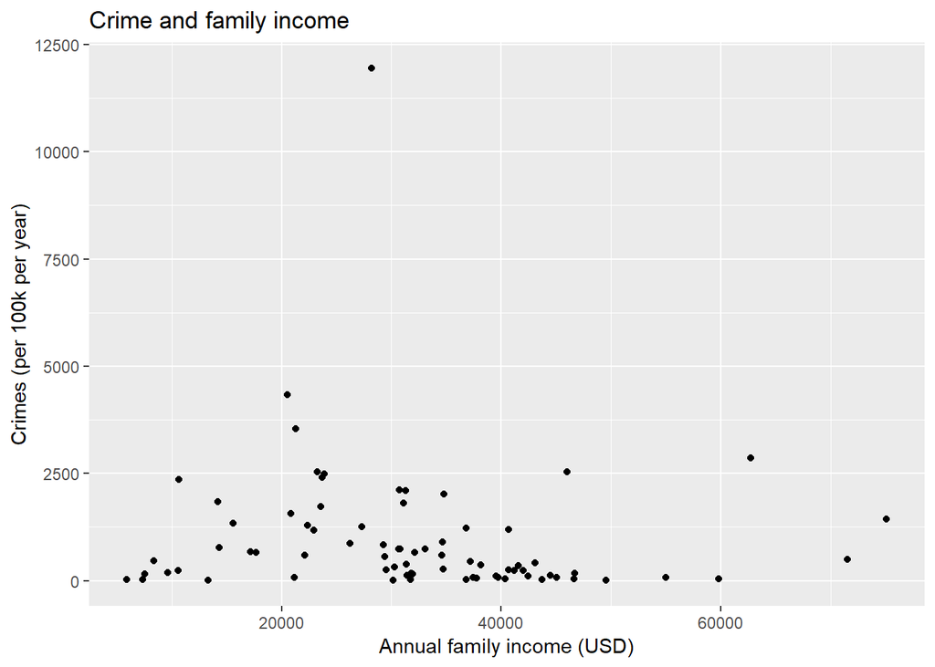

```r
#--> Scatter plot with lm on crime/family income
family_income <- ggplot() +
  geom_point(data=crime_counts_df, mapping=aes(x=FAMINC, y=NormCounts)) +
  ylim(0, NA) +
  ggtitle("Crime and family income") +
  xlab("Annual family income (USD)") +
  ylab("Crimes (per 100k per year)")

family_income
```

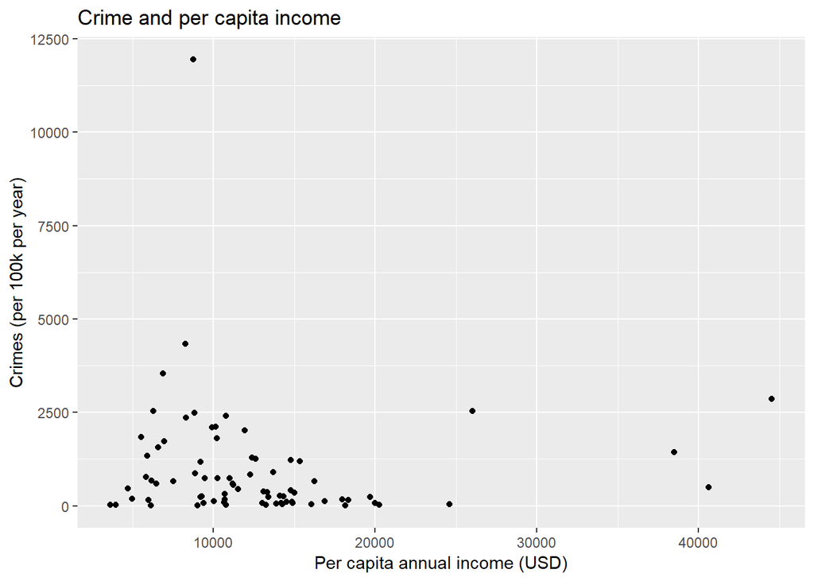

```r
#--> Scatter plot with lm on crime/per cap income
percap_income <- ggplot() +
  geom_point(data=crime_counts_df, mapping=aes(x=PERCAPINC, y=NormCounts)) +
  ylim(0, NA) +
  ggtitle("Crime and per capita income") +
  xlab("Per capita annual income (USD)") +
  ylab("Crimes (per 100k per year)")

percap_income
```

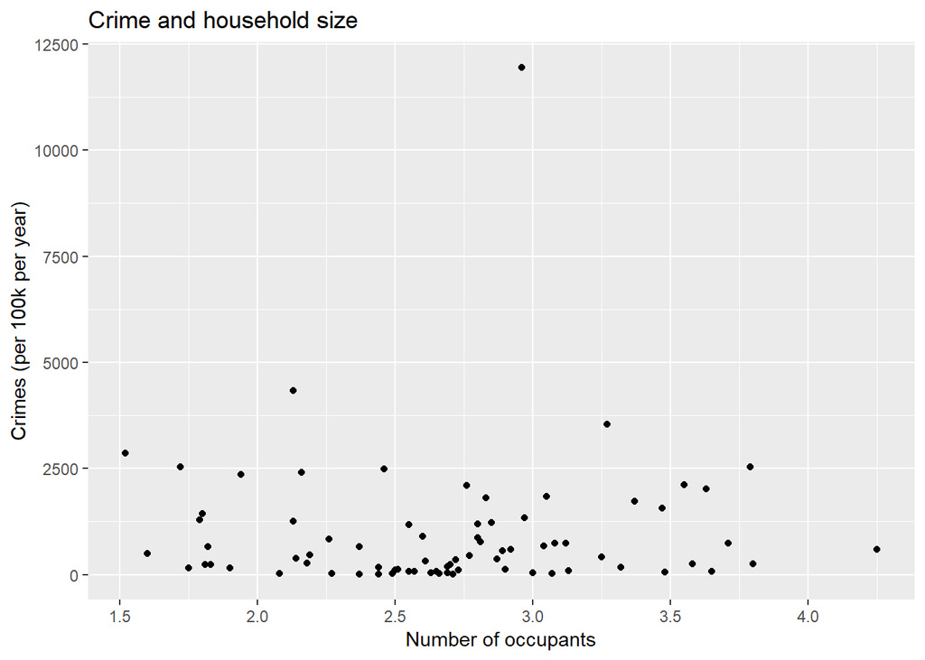

```r
#--> Scatter of crime vs household size
house_size <- ggplot() +
  geom_point(data=crime_counts_df, mapping=aes(x=AverageHouseholdSize, y=NormCounts)) +
  ylim(0, NA) +
  ggtitle("Crime and household size") +
  xlab("Number of occupants") +
  ylab("Crimes (per 100k per year)")

house_size
```

```r
#--> Clean up a bit
crime_counts_df <- crime_counts_df %>%
  mutate(BlackPercent = BlackorAfricanAmericanalone / TotalPopulation) %>%
  mutate(WhitePercent = Whitealone / TotalPopulation) %>%
  mutate(OccupiedVsVacant = OccupiedHousingUnits / VacantHousingUnits) %>%
  mutate(VacantPercent = VacantHousingUnits / TotalHousingUnits)
```

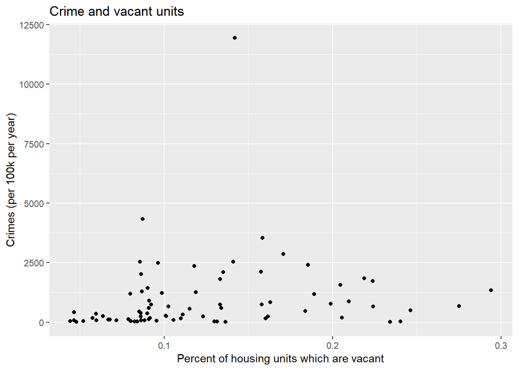

```r
#--> Scatter of crime vs vacant
vacant <- ggplot() +
  geom_point(data=crime_counts_df, mapping=aes(x=VacantPercent, y=NormCounts)) +
  ylim(0, NA) +
  ggtitle("Crime and vacant units") +
  xlab("Percent of housing units which are vacant") +
  ylab("Crimes (per 100k per year)")

vacant
```

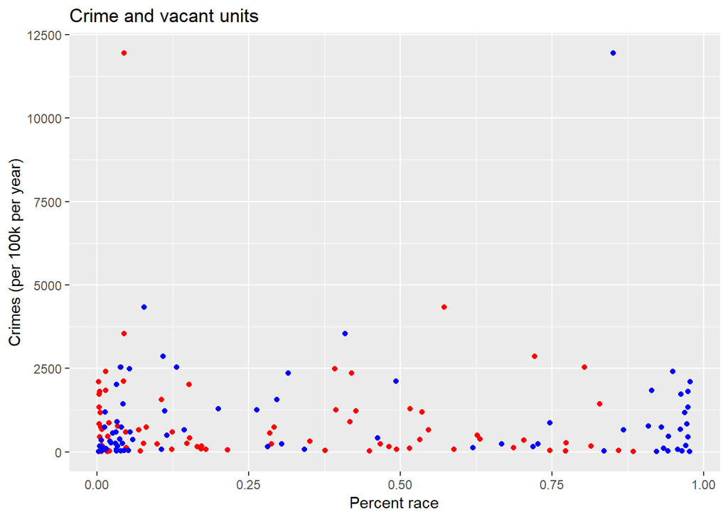

```r
#--> Scatter of crime vs race
race <- ggplot() +
  geom_point(data=crime_counts_df, mapping=aes(x=WhitePercent, y=NormCounts), color = 'red') +
  geom_point(data=crime_counts_df, mapping=aes(x=BlackPercent, y=NormCounts), color = 'blue') +
  ylim(0, NA) +
  ggtitle("Crime and vacant units") +
  xlab("Percent race") +
  ylab("Crimes (per 100k per year)")

race
```